# Manipulação de dados com R

Fernando Almeida Barbalho

21/09/2020

## Leitura de arquivo

O primeiro passo para começar a consumir dados de uma tabela é a sua leitura e armazenamento em memória.

Veja abaixo um exemplo do consumo de uma tabela que tem os dados de despesas em educação dos municípios dos estados do Ceará e Pernambuco entre os anos 2015 e 2019.

```r
#install.packages("readr")
library(readr)
# A função read_csv se encarrega de fazer a leitura do arquivo de dados e atribuir o resultado para o dataframe desp_educacao_ce_pe

desp_educacao_ce_pe <- read_csv("desp_educacao_ce_pe.csv")

#Para confirmar que a exceução foi realizada com suecesso vamos usar a funçào head() que retora por default as 6 primeiras linhas

head(desp_educacao_ce_pe)
```

```
## # A tibble: 6 x 15
##   AN_EXERCICIO NR_PERIODO IN_PERIODICIDADE CO_ESFERA CO_PODER ID_ENTE
##          <dbl>      <dbl> <chr>            <chr>     <chr>      <dbl>
## 1         2016          2 B                M         E        2607653
## 2         2016          4 B                M         E        2303501
## 3         2016          3 B                M         E        2606200
## 4         2016          5 B                M         E        2301109
## 5         2017          3 B                M         E        2602209
## 6         2015          3 B                M         E        2305407
## # ... with 9 more variables: NO_ENTE <chr>, SG_ENTE <chr>,
## #   fase_despesa <chr>, funcao <chr>, VALUE <dbl>, QT_HABITANTE <dbl>,
## #   ELEMENTLABEL <chr>, DT_STATUS_COLETA <dttm>, dh_consulta <chr>
```

## Acréscimo de colunas

Muitas vezes nossas análises requerem que trabalhemos com colunas que podem ser cosntruídas a partir de outras colunas das tabelas. No caso específico das despesas com educação, pode ser interessante que queiramos trabalhar com a infomração de despesa por habiatantes, criando portanto uma nova coluna a partir dessas outras duas já previamente existentes.

```r
#install.packages("dplyr")
library(dplyr)
# A library dplyr contém umas série de funções e operadores que facilitam o trabalho de dados
# um dos operadores é o pipe %>% que informa que uma determinada operação vai ser executada sobre a tabela
# No caso abaixo, o operador está indicando que vai ser feita a operação de mudança na estrturua da tabela usando a função mutate
# No caso específico, a função mutate cria uma nova coluna a partir dos valores de duas colunas já existentes
desp_educacao_ce_pe<-
  desp_educacao_ce_pe %>%
  mutate(despesa_por_habitante = VALUE/QT_HABITANTE )

#Para saber se funcionou a criação dessa coluna podemos pedir para exibir apenas um sub-conjunto de colunas usando a funcão select. No caso vamos exibir as variáveis AN_EXERCIOCIO, NR_PERIODO, NO_ENTE,despesa_por_habitante

head(
desp_educacao_ce_pe %>%
  select(AN_EXERCICIO, NR_PERIODO, NO_ENTE,despesa_por_habitante))
```

```
## # A tibble: 6 x 4
##   AN_EXERCICIO NR_PERIODO NO_ENTE    despesa_por_habitante
##          <dbl>      <dbl> <chr>                      <dbl>
## 1         2016          2 Itambé                     88.6
## 2         2016          4 Cascavel                    5.03
## 3         2016          3 Goiana                     81.9
## 4         2016          5 Aracati                   129.
## 5         2017          3 Bom Jardim                129.
## 6         2015          3 Icó                       148.
```

## Filtros

Uma funcionalidade muito comum em trabalho com dados é fazer filtros. A ideia é que os dados sejam recortados para ficar apenas o que interessa para uma análise em particular. Vamos por exemplo filtrar as linhas da tabela que correspondem aos anos de 2018 e 2019

```r
# A função filter é a que é responsável por realizar os filtros.
# Como o filtro envolve mais de um elemento, usamos o operador %in%

desp_educacao_ce_pe %>%
  filter(AN_EXERCICIO %in% c(2018,2019))
```

```
## # A tibble: 6,030 x 16
##    AN_EXERCICIO NR_PERIODO IN_PERIODICIDADE CO_ESFERA CO_PODER ID_ENTE
##           <dbl>      <dbl> <chr>            <chr>     <chr>      <dbl>
##  1         2018          5 B                M         E        2608404
##  2         2019          1 B                M         E        2306108
##  3         2018          6 B                M         E        2608909
##  4         2018          5 B                M         E        2301802
##  5         2018          4 B                M         E        2310001
##  6         2018          2 B                M         E        2312908
##  7         2018          1 B                M         E        2305902
##  8         2019          1 B                M         E        2600203
##  9         2018          5 B                M         E        2601706
## 10         2018          4 B                M         E        2612208
## # ... with 6,020 more rows, and 10 more variables: NO_ENTE <chr>,
## #   SG_ENTE <chr>, fase_despesa <chr>, funcao <chr>, VALUE <dbl>,
## #   QT_HABITANTE <dbl>, ELEMENTLABEL <chr>, DT_STATUS_COLETA <dttm>,
## #   dh_consulta <chr>, despesa_por_habitante <dbl>
```

## Agrupamentos

Com frequência é necessário que os dados sejam agrupados pro um sub-conjunto de colunas e em seguida um valor é sumarizado. Podemos ver por exemplo quanto se gastou por ano no conjuntos dos municípios de Pernambuco e Ceará

```r
#Para fazer agrupamentos, usamos a função group_by

desp_educacao_ce_pe %>%
  group_by(AN_EXERCICIO, SG_ENTE) %>%
  summarise(
    sum(VALUE))
```

```
## # A tibble: 10 x 3
## # Groups:   AN_EXERCICIO [5]
##    AN_EXERCICIO SG_ENTE `sum(VALUE)`
##           <dbl> <chr>          <dbl>
##  1         2015 CE       4390219700.
##  2         2015 PE       5087730053.
##  3         2016 CE       5000179934.
##  4         2016 PE       5674769536.
##  5         2017 CE       5690224249.
##  6         2017 PE       5909338196.
##  7         2018 CE       6463148420.
##  8         2018 PE       6591411280.
##  9         2019 CE       7168551275.
## 10         2019 PE       6808669658.
```

## Gráficos de box-plot e viloino

Gráficos que mostram a distribuição são importantes para comparar como so dados se distribuem pr categorias. Podemos pr exemplo comparar a distribuição dos valores gastos em educação por habitante para cada um dos dois estados, para o ano de 2019.

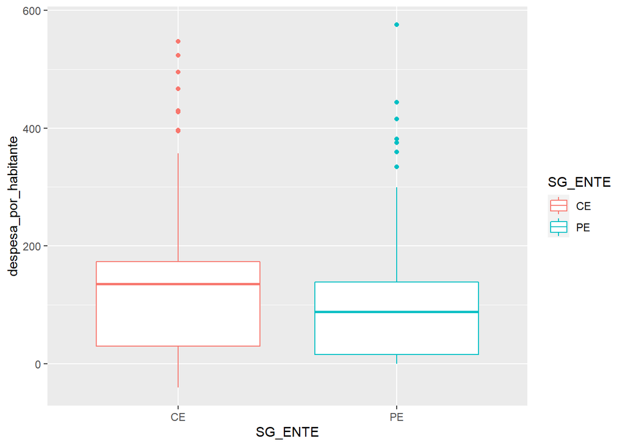

```r
#install.packages("ggplot2")
# A biblioteca ggplot2 permite a cosntrução de gráficos poderosos usando a linguagem R
library(ggplot2)

# A função geom_boxplot indica que o tipo de gráfico que vai ser desenhado será box-plot
#A função aes indica alguns parâmetros da estetica do gráfico: os valores que vão ficar nos eixos x e y e a partir de qual variável as cores de controno serão diferenciadas


desp_educacao_ce_pe %>%
  filter(AN_EXERCICIO == 2019) %>%
  ggplot() +
  geom_boxplot(aes(x= SG_ENTE, y= despesa_por_habitante, color= SG_ENTE))
```

Uma outra alternativa para visualização da distribuição é através do gráfico de violino

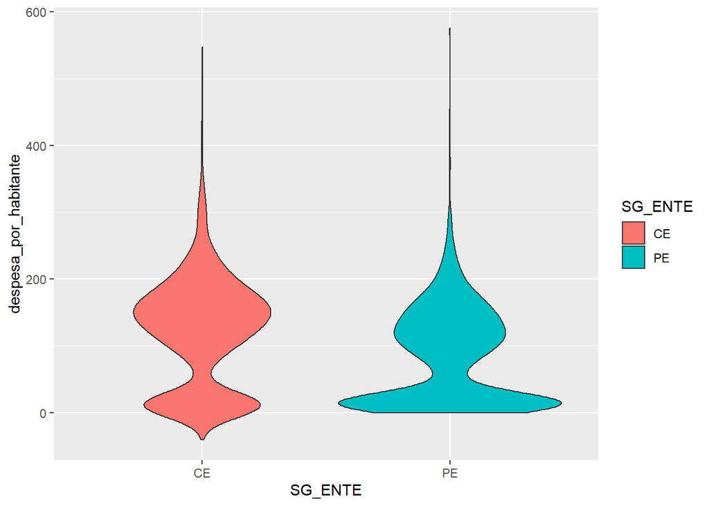

```r
# A função geom_boxplot indica que o tipo de gráfico que vai ser desenhado será box-plot
#A função aes indica alguns parâmetros da estetica do gráfico: os valores que vão ficar nos eixos x e y e a partir de qual variável as cores de preencimento do gráfico serão diferenciadas


desp_educacao_ce_pe %>%
  filter(AN_EXERCICIO == 2019) %>%
  ggplot() +
  geom_violin(aes(x= SG_ENTE, y= despesa_por_habitante, fill= SG_ENTE))
```

## Relacionamento com outras tabelas e gerando um mapa

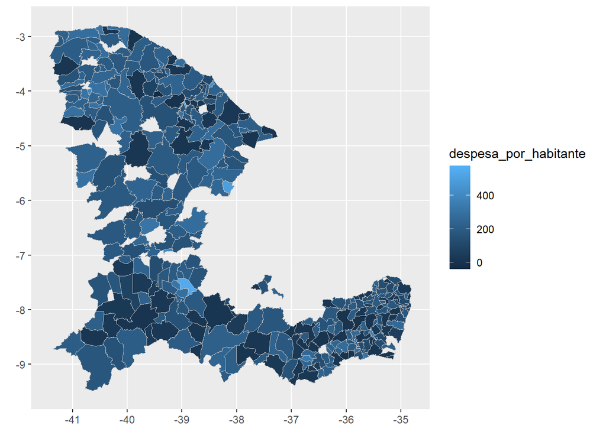

```r
#install.packages("geobr")
#install.packages("sf")
library(geobr)
library(sf)
# A library geobr é usada para fornecer dados cartográficos dos municípios

#Busca as informações cartográficas dos municípios brasileiros
#essas informações vão estar presentes na tabela muni
muni <- read_municipality( year=2010, showProgress = FALSE )


#para que duas taelas se relacionem precisam preferencialmente ter campos chaves com o mesmo nome, daí que é necessário se criar uma nova coluna na tabela desp_educacao. Na tabela muni existe um coluna com esse nome que tem o mesmo significado que  a coluna ID_ENTE, no caso, o código de IBGE do município. esse mesmo raciocínio se aplica à criaçao da coluna abbrev_state


desp_educacao_ce_pe %>%
  filter(AN_EXERCICIO == 2019,
         NR_PERIODO == 6) %>%
  mutate(code_muni = ID_ENTE,
         abbrev_state = SG_ENTE ) %>%
  inner_join(muni) %>%
  ggplot() +
  geom_sf(aes(fill= despesa_por_habitante, geometry = geom) , color="gray", size=.15)  +
  geom_sf(aes(fill= despesa_por_habitante, geometry = geom) , color="gray", size=.15)
```

## Salvando dados

Por fim quando você tiver concluído os seus tratamentos de dados, tavelz seja conveniente salvar esses dados para uso em outras situações ou mesmo em outras ferramentas.

```r
write.csv2(desp_educacao_ce_pe, file= "trabalho_dados.csv")
```